# Coronary Disease Data Analysis

Paul G. Smith

10/10/2019

## Coronary Disease Data Analysis

This is an example analysis in R to showcase some of the methods and tools available to analyze a sample dataset. Below is a link to the heart disease data sets that can be used in this analysis. While each study contains a broad range of data collected many participants, this analysis will focus on a core set of 14 variables from one of the studies (cleveland.data).

This file describes the contents of the heart-disease directory available at https:/https://archive.ics.uci.edu/ml/machine-learning-databases/heart-disease/

This directory contains 4 databases concerning heart disease diagnosis. All attributes are numeric-valued. The data was collected from the four following locations:

```
 1. Cleveland Clinic Foundation (cleveland.data)
 2. Hungarian Institute of Cardiology, Budapest (hungarian.data)
 3. V.A. Medical Center, Long Beach, CA (long-beach-va.data)
 4. University Hospital, Zurich, Switzerland (switzerland.data)
```

Each database has the same instance format. While the databases have 76 raw attributes, only 14 of them are actually used. Thus I’ve taken the liberty of making 2 copies of each database: one with all the attributes and 1 with the 14 attributes actually used in past experiments.

The authors of the databases have requested:

[output not shown]

First step in this process is to load the required libraies.

The next step is to load the data from the CSV file in the main directory, to name each of the columns, and then take a quick look at the initial structure of the data.

```r
chd <- read.csv2("cleveland.csv", sep=",", as.is=TRUE)
colnames(chd) <- c("age","sex","cp","trestbps","chol","fbs","restecg","thalach",
                   "exang","oldpeak","slope","ca","thal","outcome")
str(chd)
```

```
## 'data.frame':    302 obs. of  14 variables:
##  $ age     : chr  "67.0" "67.0" "37.0" "41.0" ...
##  $ sex     : chr  "1.0" "1.0" "1.0" "0.0" ...
##  $ cp      : chr  "4.0" "4.0" "3.0" "2.0" ...
##  $ trestbps: chr  "160.0" "120.0" "130.0" "130.0" ...
##  $ chol    : chr  "286.0" "229.0" "250.0" "204.0" ...
##  $ fbs     : chr  "0.0" "0.0" "0.0" "0.0" ...
##  $ restecg : chr  "2.0" "2.0" "0.0" "2.0" ...
##  $ thalach : chr  "108.0" "129.0" "187.0" "172.0" ...
##  $ exang   : chr  "1.0" "1.0" "0.0" "0.0" ...
##  $ oldpeak : chr  "1.5" "2.6" "3.5" "1.4" ...
##  $ slope   : chr  "2.0" "2.0" "3.0" "1.0" ...
##  $ ca      : chr  "3.0" "2.0" "0.0" "0.0" ...
##  $ thal    : chr  "3.0" "7.0" "3.0" "3.0" ...
##  $ outcome : int  2 1 0 0 0 3 0 2 1 0 ...
```

Next we need to change the type of the variables which were imported as character strings (chr), and set the levels for the factors. There is a document in the main directory which explains each variable and the possible values in the data set (see heart-disease-names.txt)

```r
# convert age to a numeric variable
chd$age <- as.numeric(chd$age)
# convert sex to a factor with two values
chd$sex <- as.factor(as.integer(chd$sex))
levels(chd$sex) <- c("female","male")
# convert cp to a factor with four values
chd$cp <- as.factor(as.integer(chd$cp))
levels(chd$cp) <- c("typical angina","atypical angina",
                     "non-anginal pain","asymptomatic")
# convert trestbps to a numeric variable
chd$trestbps <- as.numeric(chd$trestbps)
# convert chol to a numeric variable
chd$chol <- as.numeric(chd$chol)
# convert fbs to a logical variable (True/False)
chd$fbs <- as.logical(as.integer(chd$fbs))
# convert restecg to a factor with three values
chd$restecg <- as.factor(as.integer(chd$restecg))
levels(chd$restecg) <- c("normal","ST-T wave abnormality",
                         "left ventricular hypertrophy")
# convert thalach to a numeric variable
chd$thalach <- as.numeric(chd$thalach)
# convert exang to a factor with two values
chd$exang <- as.factor(as.integer(chd$exang))
levels(chd$exang) <- c("no","yes")
# convert slope to a factor with three values
chd$slope <- as.factor(as.integer(chd$slope))
levels(chd$slope) <- c("upsloping","flat","downsloping")
# convert ca to a numeric variable
chd$ca <- as.numeric(chd$ca)
# convert thal to a factor with three values
chd$thal <- as.factor(as.integer(chd$thal))
levels(chd$thal) <- c("normal","fixed defect","reversable defect")
# convert outcome to a factor
chd$outcome <- as.factor(as.integer(chd$outcome))

# look at the first 10, last 10 rows, and structure of the dataset
head(chd)
```

```
##   age    sex               cp trestbps chol   fbs
## 1  67   male     asymptomatic      160  286 FALSE
## 2  67   male     asymptomatic      120  229 FALSE
## 3  37   male non-anginal pain      130  250 FALSE
## 4  41 female  atypical angina      130  204 FALSE
## 5  56   male  atypical angina      120  236 FALSE
## 6  62 female     asymptomatic      140  268 FALSE
##                        restecg thalach exang oldpeak       slope ca
## 1 left ventricular hypertrophy     108   yes     1.5        flat  3
## 2 left ventricular hypertrophy     129   yes     2.6        flat  2
## 3                       normal     187    no     3.5 downsloping  0
## 4 left ventricular hypertrophy     172    no     1.4   upsloping  0
## 5                       normal     178    no     0.8   upsloping  0
## 6 left ventricular hypertrophy     160    no     3.6 downsloping  2
##                thal outcome
## 1            normal       2
## 2 reversable defect       1
## 3            normal       0
## 4            normal       0
## 5            normal       0
## 6            normal       3
```

```r
tail(chd)
```

```
##     age    sex               cp trestbps chol   fbs
## 297  57 female     asymptomatic      140  241 FALSE
## 298  45   male   typical angina      110  264 FALSE
## 299  68   male     asymptomatic      144  193  TRUE
## 300  57   male     asymptomatic      130  131 FALSE
## 301  57 female  atypical angina      130  236 FALSE
## 302  38   male non-anginal pain      138  175 FALSE
##                          restecg thalach exang oldpeak     slope ca
## 297                       normal     123   yes     0.2      flat  0
## 298                       normal     132    no     1.2      flat  0
## 299                       normal     141    no     3.4      flat  2
## 300                       normal     115   yes     1.2      flat  1
## 301 left ventricular hypertrophy     174    no     0.0      flat  1
## 302                       normal     173    no     0.0 upsloping NA
##                  thal outcome
## 297 reversable defect       1
## 298 reversable defect       1
## 299 reversable defect       2
## 300 reversable defect       3
## 301            normal       1
## 302            normal       0
```

```r
dim(chd)
```

```
## [1] 302  14
```

```r
str(chd)
```

```
## 'data.frame':    302 obs. of  14 variables:
##  $ age     : num  67 67 37 41 56 62 57 63 53 57 ...
##  $ sex     : Factor w/ 2 levels "female","male": 2 2 2 1 2 1 1 2 2 2 ...
##  $ cp      : Factor w/ 4 levels "typical angina",..: 4 4 3 2 2 4 4 4 4 4 ...
##  $ trestbps: num  160 120 130 130 120 140 120 130 140 140 ...
##  $ chol    : num  286 229 250 204 236 268 354 254 203 192 ...
##  $ fbs     : logi  FALSE FALSE FALSE FALSE FALSE FALSE ...
##  $ restecg : Factor w/ 3 levels "normal","ST-T wave abnormality",..: 3 3 1 3 1 3 1 3 3 1 ...
##  $ thalach : num  108 129 187 172 178 160 163 147 155 148 ...
##  $ exang   : Factor w/ 2 levels "no","yes": 2 2 1 1 1 1 2 1 2 1 ...
##  $ oldpeak : chr  "1.5" "2.6" "3.5" "1.4" ...
##  $ slope   : Factor w/ 3 levels "upsloping","flat",..: 2 2 3 1 1 3 1 2 3 2 ...
##  $ ca      : num  3 2 0 0 0 2 0 1 0 0 ...
##  $ thal    : Factor w/ 3 levels "normal","fixed defect",..: 1 3 1 1 1 1 1 3 3 2 ...
##  $ outcome : Factor w/ 5 levels "0","1","2","3",..: 3 2 1 1 1 4 1 3 2 1 ...
```

Next, let’s take a look at the distribution of data within each variable (column). The summary function will be used to provide a different set of descriptive statistics, depending on the type of variable used.

- Numeric Variables - summary() provides the range, quartiles, median, and mean.
- Character variables - summary() only provides the length and class (chr) of the variable.
- Factor variables - summary() provides a the label and count for each of the factor levels.
- Logical variables - summay() provides a count of TRUE and FALSE values.

```r
summary(chd)
```

```
##       age            sex                     cp         trestbps
##  Min.   :29.00   female: 97   typical angina  : 22   Min.   : 94.0
##  1st Qu.:48.00   male  :205   atypical angina : 50   1st Qu.:120.0
##  Median :55.50                non-anginal pain: 86   Median :130.0
##  Mean   :54.41                asymptomatic    :144   Mean   :131.6
##  3rd Qu.:61.00                                       3rd Qu.:140.0
##  Max.   :77.00                                       Max.   :200.0
##
##       chol          fbs                                  restecg
##  Min.   :126.0   Mode :logical   normal                      :151
##  1st Qu.:211.0   FALSE:258       ST-T wave abnormality       :  4
##  Median :241.5   TRUE :44        left ventricular hypertrophy:147
##  Mean   :246.7
##  3rd Qu.:275.0
##  Max.   :564.0
##
##     thalach      exang       oldpeak                  slope
##  Min.   : 71.0   no :203   Length:302         upsloping  :142
##  1st Qu.:133.2   yes: 99   Class :character   flat       :140
##  Median :153.0             Mode  :character   downsloping: 20
##  Mean   :149.6
##  3rd Qu.:166.0
##  Max.   :202.0
##
##        ca                        thal     outcome
##  Min.   :0.0000   normal           :166   0:163
##  1st Qu.:0.0000   fixed defect     : 17   1: 55
##  Median :0.0000   reversable defect:117   2: 36
##  Mean   :0.6745   NA's             :  2   3: 35
##  3rd Qu.:1.0000                           4: 13
##  Max.   :3.0000
##  NA's   :4
```

The rest to be integrated into this article.

```r
# group1: no heart disease (outcome is 0)
group1 <- chd[chd$outcome==0,]

# group12: nheart disease (outcome is 1, 2, 3, or 4)
group2 <- chd[chd$outcome!=0,]

# check both groups total 302 rows
nrow(group1)+nrow(group2)
```

```
## [1] 302
```

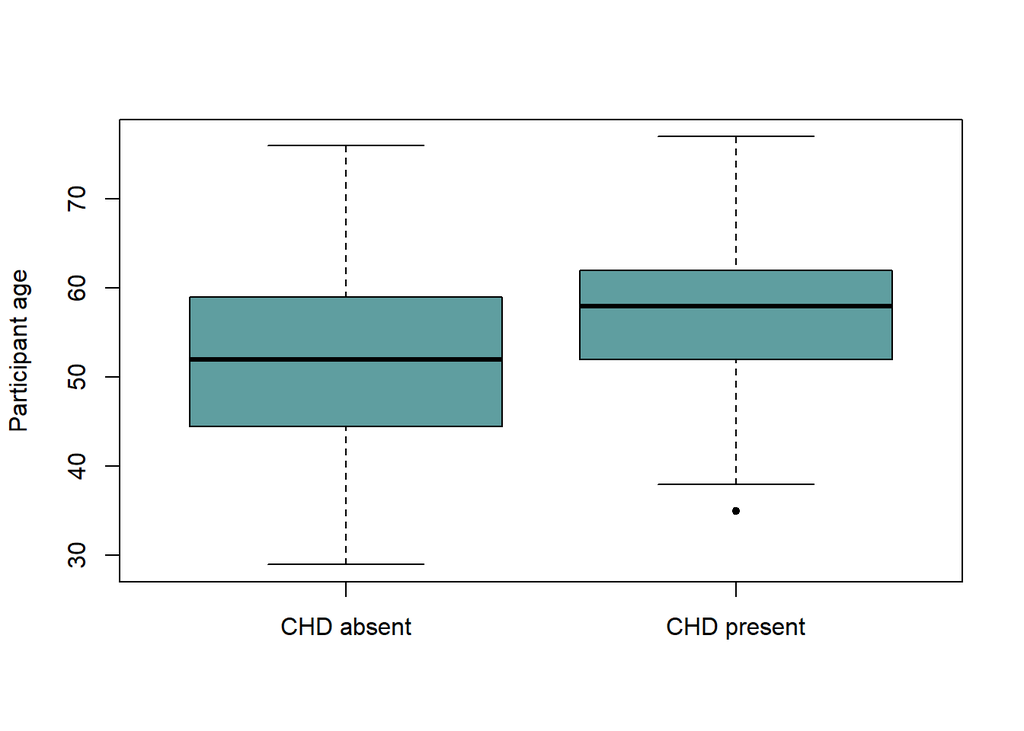

```r
# let's do some boxplots of the integer variables

#chd$age <- as.integer(chd$age)
#chd$trestbps <- as.integer(chd$trestbps)
#chd$chol <- as.integer(chd$chol)
#chd$thalach <- as.integer(chd$thalach)

boxplot(group1$age, group2$age, col="CadetBlue", pch=20,
        names=c("CHD absent", "CHD present"),
        ylab="Participant age")
```

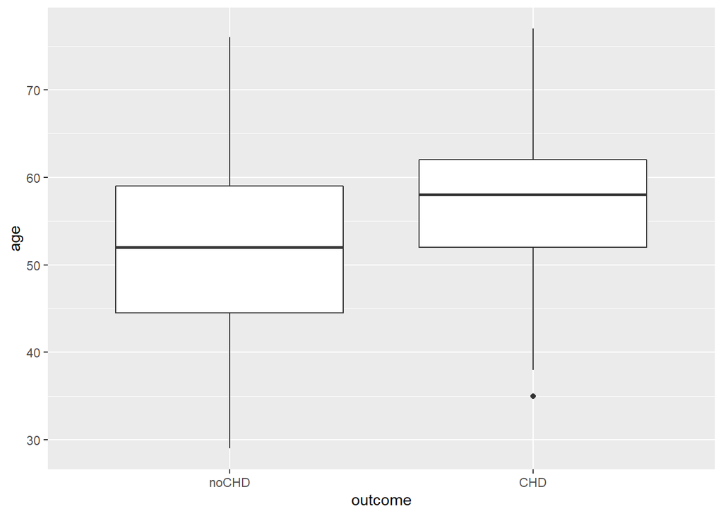

```r
# now do the same in ggplot
groupCHD <- group2
# replace all values of outcome in group2 with "1" -
groupCHD$outcome <- c(1)
CHDgroup <- rbind(group1, groupCHD)
CHDgroup$outcome <- droplevels(CHDgroup$outcome)
levels(CHDgroup$outcome) <- c("noCHD", "CHD")

a <- ggplot(CHDgroup, aes(x=outcome, y=age))
a + geom_boxplot()
```

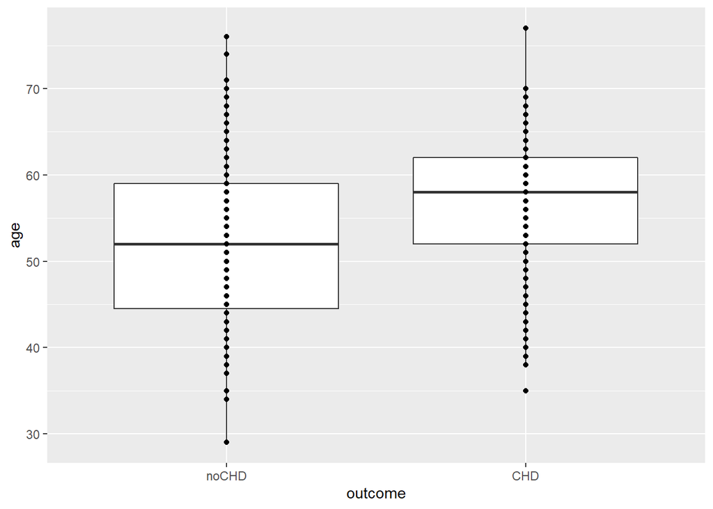

```r
a + geom_boxplot() + geom_point()
```

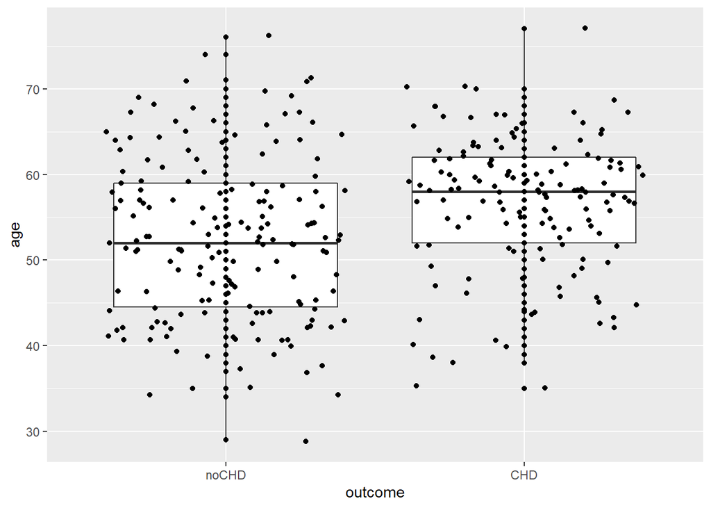

```r
a + geom_boxplot() + geom_point() + geom_jitter()
```

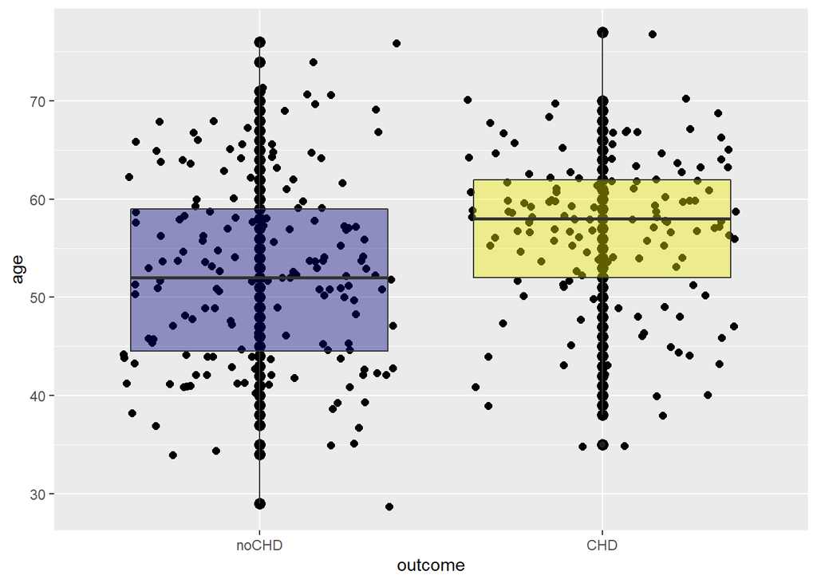

```r
a + geom_point(size=3) + geom_jitter(size=2) +
  geom_boxplot(alpha=.4, fill=c("navy","yellow2"))
```

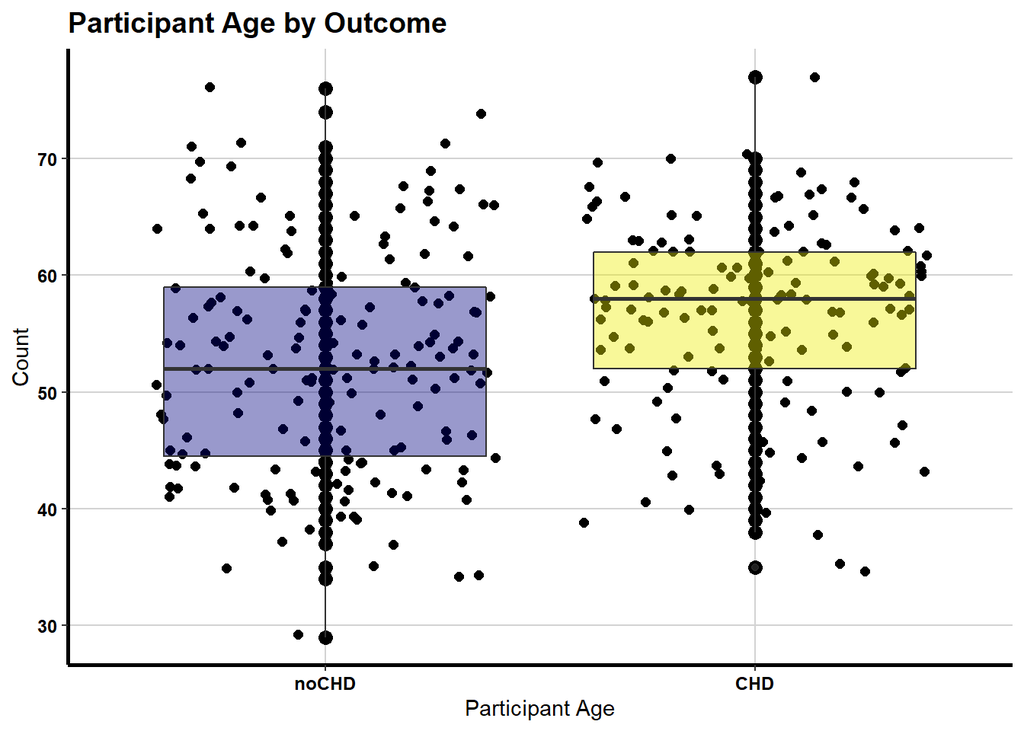

```r
a + geom_point(size=3) + geom_jitter(size=2) +
  geom_boxplot(alpha=.4, fill=c("navy","yellow2")) +
  labs(title="Participant Age by Outcome",
       y="Count", x="Participant Age") +
  theme_bw() +
  theme(axis.line = element_line(size=1, colour = "black"),
        panel.grid.major = element_line(colour = "#d3d3d3"),
        panel.grid.minor = element_blank(),
        panel.border = element_blank(), panel.background = element_blank(),
        plot.title = element_text(size = 14, family = "Tahoma", face = "bold"),
        text=element_text(family="Tahoma"),
        axis.text.x=element_text(colour="black", size = 9, face="bold"),
        axis.text.y=element_text(colour="black", size = 9, face="bold")) +
  scale_fill_brewer(palette="Accent")
```

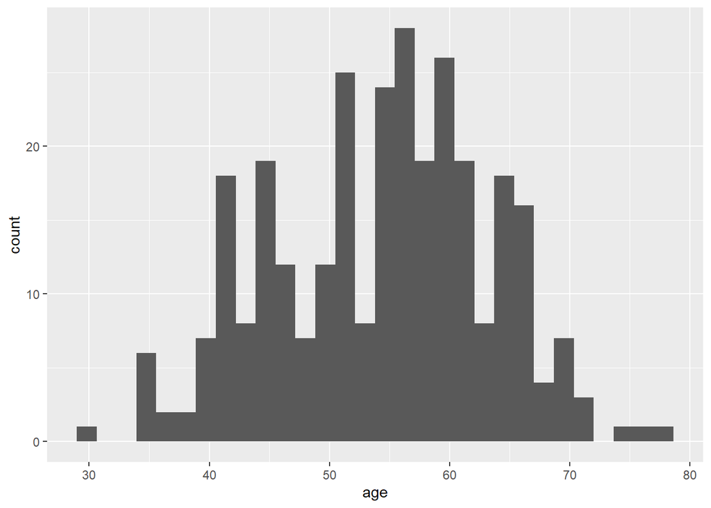

```r
b <- ggplot(CHDgroup, aes(x=age))
b +  geom_histogram(bins=30)
```

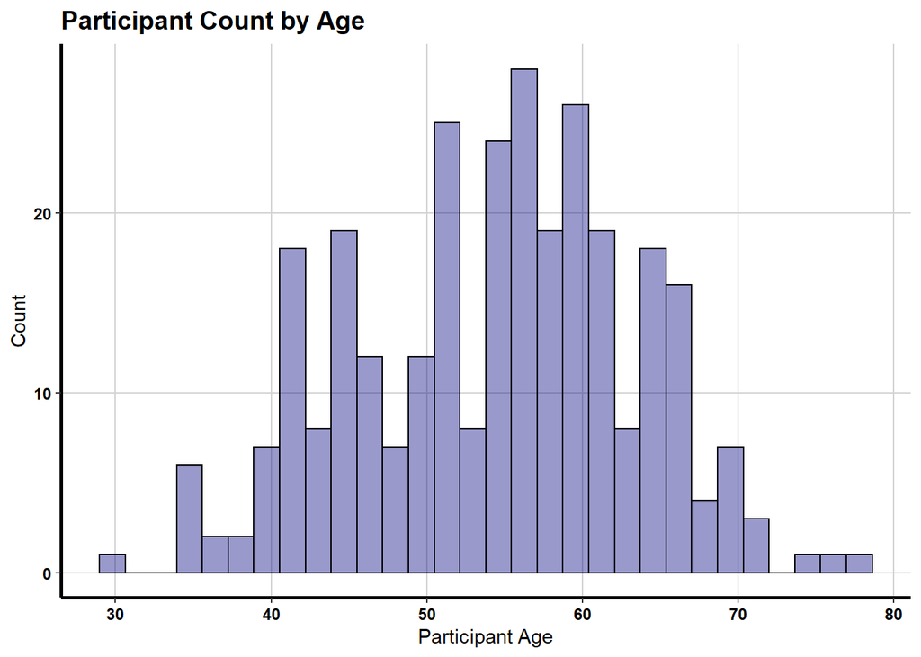

```r
b +  geom_histogram(bins=30, color="black", fill="navy", alpha=0.4) +
  labs(title="Participant Count by Age",
       y="Count", x="Participant Age") +
  theme_bw() +
  theme(axis.line = element_line(size=1, colour = "black"),
        panel.grid.major = element_line(colour = "#d3d3d3"),
        panel.grid.minor = element_blank(),
        panel.border = element_blank(), panel.background = element_blank(),
        plot.title = element_text(size = 14, family = "Tahoma", face = "bold"),
        text=element_text(family="Tahoma"),
        axis.text.x=element_text(colour="black", size = 9, face="bold"),
        axis.text.y=element_text(colour="black", size = 9, face="bold")) +
  scale_fill_brewer(palette="Accent")
```

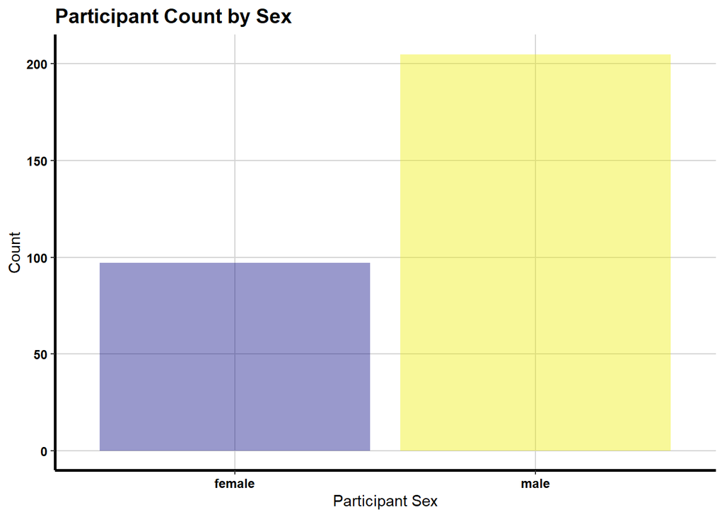

```r
ggplot(CHDgroup, aes(sex)) +
  geom_bar(fill=c("navy","yellow2"), alpha=0.4) +
  labs(title="Participant Count by Sex",
       y="Count", x="Participant Sex") +
  theme_bw() +
  theme(axis.line = element_line(size=1, colour = "black"),
        panel.grid.major = element_line(colour = "#d3d3d3"),
        panel.grid.minor = element_blank(),
        panel.border = element_blank(), panel.background = element_blank(),
        plot.title = element_text(size = 14, family = "Tahoma", face = "bold"),
        text=element_text(family="Tahoma"),
        axis.text.x=element_text(colour="black", size = 9, face="bold"),
        axis.text.y=element_text(colour="black", size = 9, face="bold")) +
  scale_fill_brewer(palette="Accent")
```

```r
df <- CHDgroup %>%
  group_by(sex) %>%
  summarize(counts = n())
df
```

```
## # A tibble: 2 x 2
##   sex    counts
##   <fct>   <int>
## 1 female     97
## 2 male      205
```

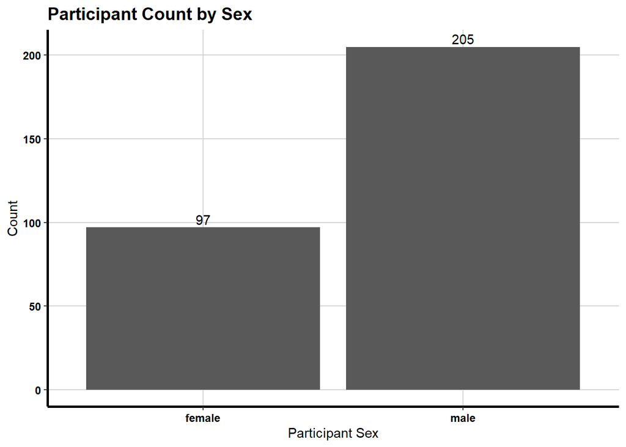

```r
c <- ggplot(df, aes(x=sex, y=counts))
c + geom_bar(stat = "identity") +
  geom_text(aes(label=counts), vjust = -0.3) +
  labs(title="Participant Count by Sex",
       y="Count", x="Participant Sex") +
  theme_bw() +
  theme(axis.line = element_line(size=1, colour = "black"),
        panel.grid.major = element_line(colour = "#d3d3d3"),
        panel.grid.minor = element_blank(),
        panel.border = element_blank(), panel.background = element_blank(),
        plot.title = element_text(size = 14, family = "Tahoma", face = "bold"),
        text=element_text(family="Tahoma"),
        axis.text.x=element_text(colour="black", size = 9, face="bold"),
        axis.text.y=element_text(colour="black", size = 9, face="bold")) +
  scale_fill_brewer(palette="Accent")
```

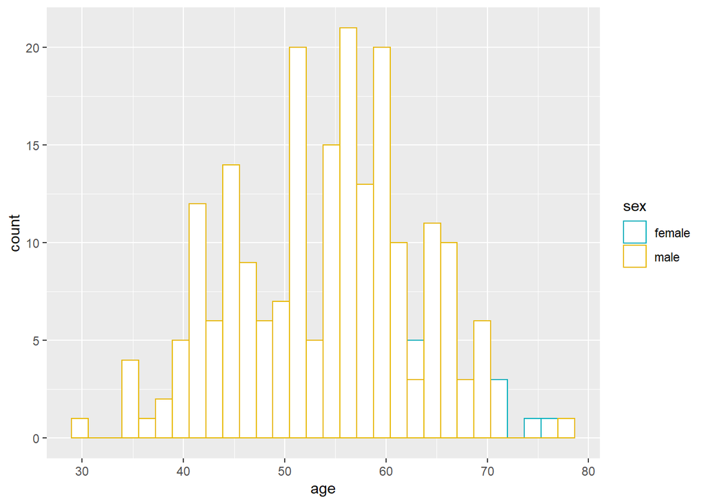

```r
d <- ggplot(CHDgroup, aes(x=age))
d +  geom_histogram(bins=30, aes(color=sex), fill="white",
                    position="identity") +
  scale_color_manual(values = c("#00AFBB", "#E7B800"))
```

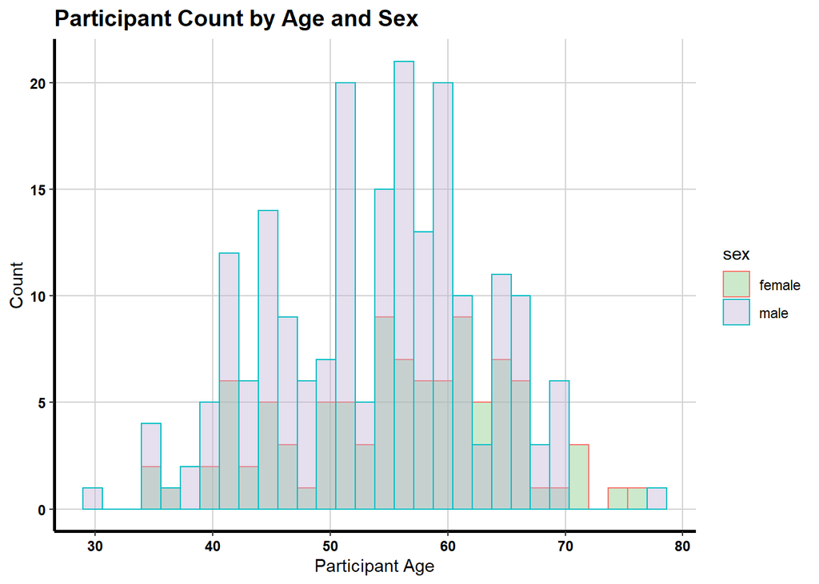

```r
d +  geom_histogram(aes(color=sex, fill=sex), alpha=0.4,
                    position="identity") +
  labs(title="Participant Count by Age and Sex",
       y="Count", x="Participant Age") +
  theme_bw() +
  theme(axis.line = element_line(size=1, colour = "black"),
        panel.grid.major = element_line(colour = "#d3d3d3"),
        panel.grid.minor = element_blank(),
        panel.border = element_blank(), panel.background = element_blank(),
        plot.title = element_text(size = 14, family = "Tahoma", face = "bold"),
        text=element_text(family="Tahoma"),
        axis.text.x=element_text(colour="black", size = 9, face="bold"),
        axis.text.y=element_text(colour="black", size = 9, face="bold")) +
  scale_fill_brewer(palette="Accent")
```

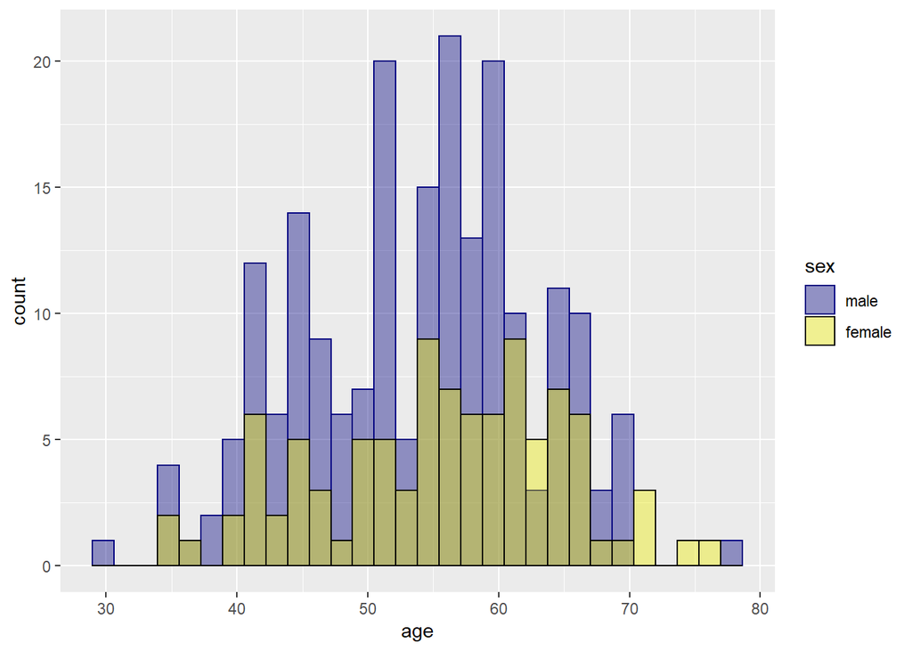

```r
df <- CHDgroup
df$sex <- factor(df$sex,
                 levels=levels(df$sex)[order(levels(df$sex),
                                             decreasing=T)])
e <- ggplot(df, aes(x=age))
e + geom_histogram(bins=30, aes(color=sex, fill=sex), alpha=0.4,
                    position="identity") +
  scale_color_manual(values = c("navy", "black")) +
  scale_fill_manual(values = c("navy", "yellow2"))
```

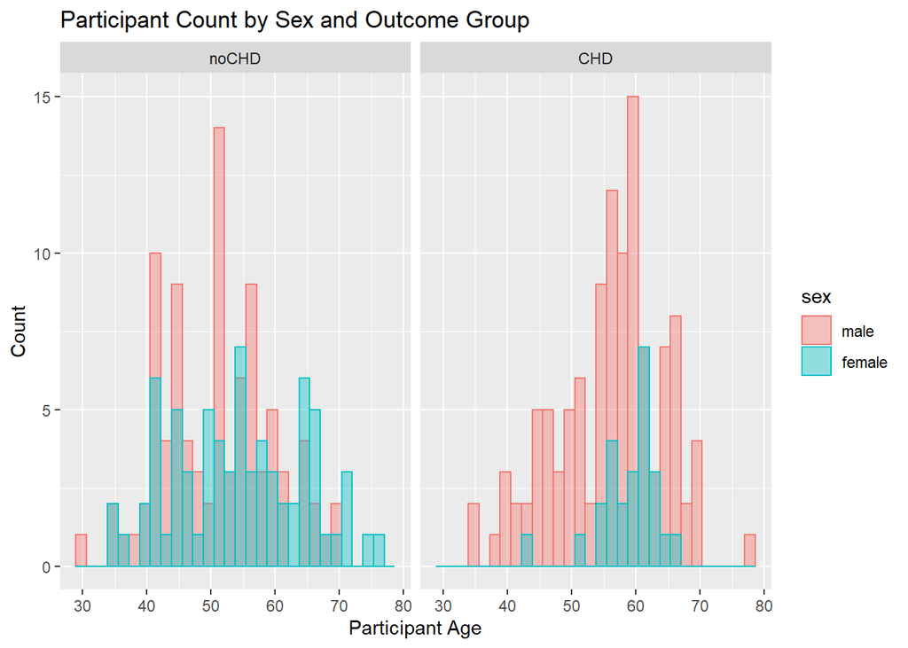

```r
e +  geom_histogram(bins=30, aes(color=sex, fill=sex), alpha=0.4,
                    position="identity") +
  labs(title="Participant Count by Sex and Outcome Group",
       y="Count", x="Participant Age") +
  facet_grid(cols=vars(outcome))
```

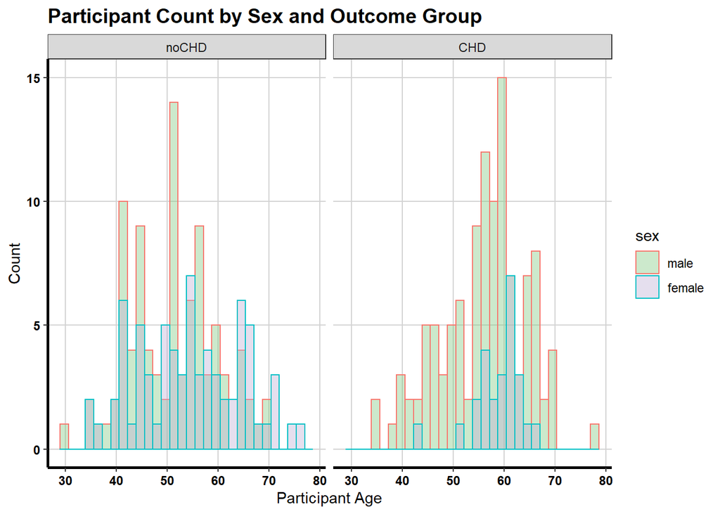

```r
e +  geom_histogram(bins=30, aes(color=sex, fill=sex),alpha=0.4,
                      position="identity") +
  labs(title="Participant Count by Sex and Outcome Group",
       y="Count", x="Participant Age") +
  facet_grid(cols=vars(outcome)) +
    theme_bw() +
    theme(axis.line = element_line(size=1, colour = "black"),
          panel.grid.major = element_line(colour = "#d3d3d3"),
          panel.grid.minor = element_blank(),
          panel.border = element_blank(), panel.background = element_blank(),
          plot.title = element_text(size = 14,
                                    family = "Tahoma", face = "bold"),
          text=element_text(family="Tahoma"),
          axis.text.x=element_text(colour="black", size = 9, face="bold"),
          axis.text.y=element_text(colour="black", size = 9, face="bold")) +
    scale_fill_brewer(palette="Accent")
```

The End….